# 63_preprocessing

### [Preprocessing](https://scikit-learn.org/stable/modules/preprocessing.html)

### [Standard Scaling](https://scikit-learn.org/stable/modules/generated/sklearn.preprocessing.StandardScaler.html#sklearn.preprocessing.StandardScaler)

- scaled data has zero mean & unit variance.

```python
print(X_scaled.mean(axis=0))
print(X_scaled.std(axis=0))
```

```
[0. 0. 0.]
[1. 1. 1.]
```

- This class implements the Transformer API to compute the mean and standard deviation on a training set, then re-apply the same transformation on the testing set. This class is hence suitable for use in the early steps of a Pipeline.

```python
from sklearn.datasets import make_classification
from sklearn.linear_model import LogisticRegression
from sklearn.model_selection import train_test_split
from sklearn.pipeline import make_pipeline
from sklearn.preprocessing import StandardScaler

X, y = make_classification(random_state=42)
X_train, X_test, y_train, y_test = train_test_split(
    X, y, random_state=42)

pipe = make_pipeline(StandardScaler(),
                     LogisticRegression()).fit(X_train,
                                               y_train)

pipe.score(X_test, y_test)
```

```
0.96
```

### [Min-Max Scaling](https://scikit-learn.org/stable/modules/generated/sklearn.preprocessing.MinMaxScaler.html#sklearn.preprocessing.MinMaxScaler) and [Max Abs Scaling](https://scikit-learn.org/stable/modules/generated/sklearn.preprocessing.MaxAbsScaler.html#sklearn.preprocessing.MaxAbsScaler)

- Another method is to scale between a min & max value (often 0-1), or so that a max absolute value of each feature is scaled to unit size.
- This provides robustness to very small standard deviations of features and preserving zero entries in sparse data.

```python
X_train = np.array([[ 1., -1.,  2.],
                    [ 2.,  0.,  0.],
                    [ 0.,  1., -1.]])

min_max_scaler = preprocessing.MinMaxScaler()
X_train_minmax = min_max_scaler.fit_transform(X_train)
X_train_minmax
```

```
array([[0.5       , 0.        , 1.        ],
       [1.        , 0.5       , 0.33333333],
       [0.        , 1.        , 0.        ]])
```

- The transformer instance can then be applied to new test data unseen during the fit: the same scaling and shifting operations will be applied to be consistent with the transformation performed on the training data.

```python
X_test = np.array([[-3., -1.,  4.]])
X_test_minmax = min_max_scaler.transform(X_test)
X_test_minmax
```

```
array([[-1.5       ,  0.        ,  1.66666667]])
```

- Viewing the scaler attributes:

```python
print(min_max_scaler.scale_)
print(min_max_scaler.min_)
```

```
[0.5        0.5        0.33333333]
[0.         0.5        0.33333333]
```

- MaxAbsScaler scales such that training data lies within [-1,+1] by dividing through the largest max value in each feature. It is meant for data already centered at zero, or sparse data.

### Scaling sparse data

- Centering sparse data destroys the sparseness - it is rarely is a sensible thing to do. However, it can make help if features are on different scales.
- `MaxAbsScaler` was designed for scaling sparse data. `StandardScaler` can also accept `scipy.sparse` matrix inputs (as long as `with_mean=False` is used). Otherwise a `ValueError` will be raised - silently centering would break the sparsity and can crash execution by allocating too much memory unintentionally. `RobustScaler` cannot be fitted to sparse inputs, but you can use the `transform` method on sparse inputs.
- Scalers accept both CSR and CSC format (see `scipy.sparse.csr_matrix` and `scipy.sparse.csc_matrix`). Any other sparse input will be converted to the CSR format. Choose the CSR or CSC representation upstream to avoid unnecessary memory copies.
- If the centered data is expected to be small, explicitly converting the input to an array using `toarray` of sparse matrices is another option.

### Scaling with outliers with [Robust Scaler](https://scikit-learn.org/stable/modules/generated/sklearn.preprocessing.RobustScaler.html#sklearn.preprocessing.RobustScaler)

- If your data contains many outliers, mean/variance scaling probably will not work very well - use `RobustScaler` as a drop-in replacement. It uses more robust estimates for the center and range of your data.

```python
from sklearn.preprocessing import RobustScaler
X = [[ 1., -2.,  2.],
     [ -2.,  1.,  3.],
     [ 4.,  1., -2.]]
transformer = RobustScaler().fit(X)
transformer.transform(X)
```

```
array([[ 0. , -2. ,  0. ],
       [-1. ,  0. ,  0.4],
       [ 1. ,  0. , -1.6]])
```

### Scaling kernel matrices with KernelCenterer

- If you have a matrix of a kernel $K$ that computes a dot product in a feature space defined by function $\phi$, `KernelCenterer` can transform the matrix so that it contains inner products in the feature space defined by $\phi$ followed by removal of the mean in that space.

```python
from sklearn.preprocessing import KernelCenterer
from sklearn.metrics.pairwise import pairwise_kernels

X = [[ 1., -2.,  2.],
     [ -2.,  1.,  3.],
     [ 4.,  1., -2.]]
K = pairwise_kernels(X, metric='linear'); print(K)

transformer = KernelCenterer().fit(K)
transformer

transformer.transform(K)
```

```
[[  9.   2.  -2.]
 [  2.  14. -13.]
 [ -2. -13.  21.]]
```

```
array([[  5.,   0.,  -5.],
       [  0.,  14., -14.],
       [ -5., -14.,  19.]])
```

### [Quantile Transforms](https://scikit-learn.org/stable/modules/generated/sklearn.preprocessing.QuantileTransformer.html#sklearn.preprocessing.QuantileTransformer)

- Puts all features into the same distribution based on $G^{-1}(F(X))$ where $F$ is a *cumulative distribution function*, $G$ the desired output distribution, and $G^{-1}$ is the quantile function of the output function.
- It computes a rank transformation, which smooths out unusual distributions & is more robust to outliers.
- It does, however, distort correlations & distances within/across features.

### Quantile Mapping to a Uniform [0..1] Distribution

```python
from sklearn.datasets import load_iris
from sklearn.model_selection import train_test_split as TTS
from sklearn.preprocessing import QuantileTransformer as QT

X, y = load_iris(return_X_y=True)
X_train, X_test, y_train, y_test = TTS(X, y, random_state=0)

qt            = QT(random_state=0)
X_train_trans = qt.fit_transform(X_train)
X_test_trans  = qt.transform(X_test)
np.percentile(X_train[:, 0], [0, 25, 50, 75, 100])
```

```
array([4.3, 5.1, 5.8, 6.5, 7.9])
```

### [Example: Map data to Normal Distributions (Box-Cox, Yeo-Johnson)](https://scikit-learn.org/stable/auto_examples/preprocessing/plot_map_data_to_normal.html)

- Power transforms are useful when [homoscedasticity](https://en.wikipedia.org/wiki/Homoscedasticity) & normality are needed.
- Below: Cox-Box & Yeo-Johnson transforms applied to *lognormal*, *chi-squared*, *weibull*, *gaussian*, *uniform* and *bimodal* distributions.
- Success depends on the dataset. Highlights importance of before/after visualization.
- Quantile Transformer forces any arbitrary distribution into a Gaussian *if enough samples are available*. It is prone to *overfitting* on small datasets - consider using a power transform instead.

```python
import numpy as np
import matplotlib.pyplot as plt

from sklearn.preprocessing import PowerTransformer as PT
from sklearn.preprocessing import QuantileTransformer as QT
from sklearn.model_selection import train_test_split as TTS
```

```python
# n_quantiles is set to the training set size rather than the default value
# to avoid a warning being raised by this example

N_SAMPLES = 1000
FONT_SIZE = 9
BINS      = 30
rng       = np.random.RandomState(304)
bc        = PT(method='box-cox')
yj        = PT(method='yeo-johnson')
qt        = QT(n_quantiles=500,
               output_distribution='normal',
               random_state=rng)
size      = (N_SAMPLES, 1)

# distributions
X_lognormal = rng.lognormal(      size=size)
X_chisq     = rng.chisquare(df=3, size=size)
X_weibull   = rng.weibull(  a=50, size=size)
X_gaussian  = rng.normal(loc=100, size=size)
X_uniform   = rng.uniform(low=0, high=1, size=size)
X_a, X_b    = rng.normal(loc=100, size=size), rng.normal(loc=105, size=size)
X_bimodal   = np.concatenate([X_a, X_b], axis=0)
```

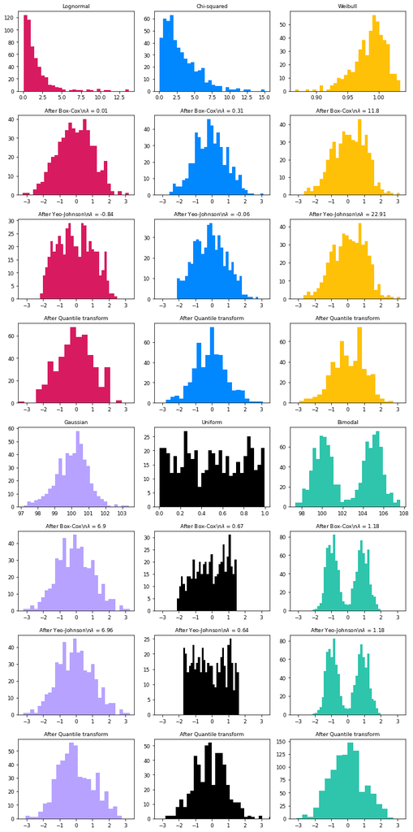

```python
distributions = [
    ('Lognormal', X_lognormal),
    ('Chi-squared', X_chisq),
    ('Weibull', X_weibull),
    ('Gaussian', X_gaussian),
    ('Uniform', X_uniform),
    ('Bimodal', X_bimodal)
]

colors = ['#D81B60', '#0188FF', '#FFC107',
          '#B7A2FF', '#000000', '#2EC5AC']

#fig, axes = plt.subplots(nrows=8, ncols=3, figsize=plt.figaspect(2))
fig, axes = plt.subplots(nrows=8, ncols=3, figsize=(10,20))
axes = axes.flatten()
axes_idxs = [(0, 3, 6, 9), (1, 4, 7, 10), (2, 5, 8, 11), (12, 15, 18, 21),
             (13, 16, 19, 22), (14, 17, 20, 23)]
axes_list = [(axes[i], axes[j], axes[k], axes[l])
             for (i, j, k, l) in axes_idxs]

for distribution, color, axes in zip(distributions, colors, axes_list):
    name, X = distribution
    X_train, X_test = TTS(X, test_size=.5)

    # perform power transforms and quantile transform
    X_trans_bc = bc.fit(X_train).transform(X_test)
    X_trans_yj = yj.fit(X_train).transform(X_test)
    X_trans_qt = qt.fit(X_train).transform(X_test)

    lmbda_bc = round(bc.lambdas_[0], 2)
    lmbda_yj = round(yj.lambdas_[0], 2)

    ax_original, ax_bc, ax_yj, ax_qt = axes
    ax_original.hist(X_train, color=color, bins=BINS)
    ax_original.set_title(name, fontsize=FONT_SIZE)
    ax_original.tick_params(axis='both', which='major', labelsize=FONT_SIZE)

    for ax, X_trans, meth_name, lmbda in zip(
            (ax_bc, ax_yj, ax_qt),
            (X_trans_bc, X_trans_yj, X_trans_qt),
            ('Box-Cox', 'Yeo-Johnson', 'Quantile transform'),
            (lmbda_bc, lmbda_yj, None)):
        ax.hist(X_trans, color=color, bins=BINS)
        title = 'After {}'.format(meth_name)
        if lmbda is not None:
            title += r'\n$\lambda$ = {}'.format(lmbda)
        ax.set_title(title, fontsize=FONT_SIZE)
        ax.tick_params(axis='both', which='major', labelsize=FONT_SIZE)
        ax.set_xlim([-3.5, 3.5])

plt.tight_layout()
```

- [Quantile Transformer](https://scikit-learn.org/stable/modules/generated/sklearn.preprocessing.QuantileTransformer.html#sklearn.preprocessing.QuantileTransformer) can also map data to a normal distribution with `output_distribution='normal'`.

```python
qt = QT(output_distribution='normal',
        random_state=0)
X_trans = qt.fit_transform(X)

print(qt.quantiles_)
```

[output not shown]

[output cut: 945 more lines]

[output not shown]

### [Normalization](https://scikit-learn.org/stable/modules/generated/sklearn.preprocessing.Normalizer.html#sklearn.preprocessing.Normalizer)

- Defined as the process of scaling individual samples to have *unit norm*. This is useful when you use a quadratic method (ex: dot-product) to measure the similarity of any sample pair.
- `normalize` transforms an array using `l1`, 'l2`or 'max` norms.
- `Normalizer` does the same using the `Transformer` API - it is therefore useful in pipelines.
- Both accept dense & sparse matrix inputs.

```python
from sklearn.preprocessing import normalize as Norm, Normalizer as Normlzr

X = [[ 1., -1.,  2.],
     [ 2.,  0.,  0.],
     [ 0.,  1., -1.]]

X_normalized = Norm(X, norm='l2')
print(X_normalized,"\n")

normalizer   = Normlzr().fit(X) # fit does nothing
normalizer.transform(X)
print(normalizer.transform([[-1.0, 1.0, 0.0]]))
```

```
[[ 0.40824829 -0.40824829  0.81649658]
 [ 1.          0.          0.        ]
 [ 0.          0.70710678 -0.70710678]]

[[-0.70710678  0.70710678  0.        ]]
```

### [Categories to Integers](https://scikit-learn.org/stable/modules/generated/sklearn.preprocessing.OrdinalEncoder.html#sklearn.preprocessing.OrdinalEncoder)

- Use `OrdinalEncoder` to transform category names to 0-*n_categories-1*.

```python
enc = preprocessing.OrdinalEncoder()
X = [['male',   'from US',     'uses Safari'],
     ['female', 'from Europe', 'uses Firefox']]
enc.fit(X)

enc.transform([['female', 'from US', 'uses Safari']])
```

```
array([[0., 1., 1.]])
```

### [Categories to one-of-K ("One Hot")](https://scikit-learn.org/stable/modules/generated/sklearn.preprocessing.OneHotEncoder.html#sklearn.preprocessing.OneHotEncoder)

- use `OneHotEncoder` to transform category names into `n_category` binary features with one equal to 1, the rest equal to 0.

```python
enc = preprocessing.OneHotEncoder()
X = [['male',   'from US',     'uses Safari'],
     ['female', 'from Europe', 'uses Firefox']]
enc.fit(X)

enc.transform([['female', 'from US', 'uses Safari'],
               ['male', 'from Europe', 'uses Safari']]).toarray()
```

```
array([[1., 0., 0., 1., 0., 1.],
       [0., 1., 1., 0., 0., 1.]])
```

- Feature values are inferred automatically from the dataset.
- They can also be specified using `categories`.

```python
enc.categories_
```

```
[array(['female', 'male'], dtype=object),
 array(['from Europe', 'from US'], dtype=object),
 array(['uses Firefox', 'uses Safari'], dtype=object)]
```

```python
genders   = ['female',      'male']
locations = ['from Africa', 'from Asia',    'from Europe', 'from US']
browsers  = ['uses Chrome', 'uses Firefox', 'uses IE',     'uses Safari']

enc = preprocessing.OneHotEncoder(categories=[genders, locations, browsers])

# Note: missing categorical values for the 2nd and 3rd feature
X = [['male',   'from US',     'uses Safari'],
     ['female', 'from Europe', 'uses Firefox']]

enc.fit(X).transform([['female', 'from Asia', 'uses Chrome']]).toarray()
```

```
array([[1., 0., 0., 1., 0., 0., 1., 0., 0., 0.]])
```

- If the training data has missing category features, it's better to specify `handle_unknown='ignore'` instead of manually setting categories.
- In this approach, unknown categories will be coded with all zeroes.

```python
enc = preprocessing.OneHotEncoder(handle_unknown='ignore')
X = [['male', 'from US', 'uses Safari'],
     ['female', 'from Europe', 'uses Firefox']]

enc.fit(X).transform([['female', 'from Asia', 'uses Chrome']]).toarray()
```

```
array([[1., 0., 0., 0., 0., 0.]])
```

- `drop` allows encoding columns into `n_categories-1` columns by specifying a category for each feature to be dropped.
- This helps avoid input matrix co-linearity. This is useful for example when using *Linear Regression* - co-linearity can cause a covariance matrix to be non-invertible.

```python
X = [['male', 'from US', 'uses Safari'],
     ['female', 'from Europe', 'uses Firefox']]

drop_enc = preprocessing.OneHotEncoder(drop='first').fit(X)
print(drop_enc.categories_)
print(drop_enc.transform(X).toarray())
```

```
[array(['female', 'male'], dtype=object), array(['from Europe', 'from US'], dtype=object), array(['uses Firefox', 'uses Safari'], dtype=object)]
[[1. 1. 1.]
 [0. 0. 0.]]
```

- Use `drop='if_binary'` if you want to drop columns for features with 2 categories.

```python
X = [['male', 'US', 'Safari'],
     ['female', 'Europe', 'Firefox'],
     ['female', 'Asia', 'Chrome']]

drop_enc = preprocessing.OneHotEncoder(drop='if_binary').fit(X)
print(drop_enc.categories_)
print(drop_enc.transform(X).toarray())
```

```
[array(['female', 'male'], dtype=object), array(['Asia', 'Europe', 'US'], dtype=object), array(['Chrome', 'Firefox', 'Safari'], dtype=object)]
[[1. 0. 0. 1. 0. 0. 1.]
 [0. 0. 1. 0. 0. 1. 0.]
 [0. 1. 0. 0. 1. 0. 0.]]
```

- `OneHotEncoder` supports missing values by considering them as an additional category:

```python
X = [['male', 'Safari'],
     ['female', None],
     [np.nan, 'Firefox']]

enc = preprocessing.OneHotEncoder(handle_unknown='error').fit(X)
print(enc.categories_)
print(enc.transform(X).toarray())
```

```
[array(['female', 'male', nan], dtype=object), array(['Firefox', 'Safari', None], dtype=object)]
[[0. 1. 0. 0. 1. 0.]
 [1. 0. 0. 0. 0. 1.]
 [0. 0. 1. 1. 0. 0.]]
```

- If a feature contains both np.nan and None, they will treated separately.

```python
X = [['Safari'], [None], [np.nan], ['Firefox']]

enc = preprocessing.OneHotEncoder(handle_unknown='error').fit(X)
print(enc.categories_)
print(enc.transform(X).toarray())
```

```
[array(['Firefox', 'Safari', None, nan], dtype=object)]
[[0. 1. 0. 0.]
 [0. 0. 1. 0.]
 [0. 0. 0. 1.]
 [1. 0. 0. 0.]]
```

### Quantization, aka Binning

KBinsDiscretizer partitions features into $k$ bins.

- The output is, by default, one-hot encoded into a sparse matrix. This is controlled with `encode`.
- The bin edges are computed during `fit` and define the intervals (along with the number of bins.)

```python
X = np.array([[ -3., 5., 15 ],
              [  0., 6., 14 ],
              [  6., 3., 11 ]])

est = preprocessing.KBinsDiscretizer(n_bins=[3, 2, 2],
                                     encode='ordinal').fit(X)
est.transform(X)
```

```
array([[0., 1., 1.],
       [1., 1., 1.],
       [2., 0., 0.]])
```

- Discretization is similar to constructing histograms for continuous data.
  - *histograms focus on counting features* in particular bins.
  - *discretization assigns feature values to these bins*.
- `KBinsDiscretizer` uses `strategy` to select a binning strategy.
  - ‘uniform’: uses constant-width bins.
  - ‘quantile’: uses the quantiles values to have equally populated bins.
  - ‘kmeans’: bins based on independent k-means clustering for each feature.
- You can specify custom bins with a callable (in this case, `pandas.cut`) to `FunctionTransformer`.

```python
import pandas as pd
import numpy as np

bins   = [0,         1,     13,     20,      60, np.inf]
labels = ['infant', 'kid', 'teen', 'adult', 'senior citizen']

transformer = preprocessing.FunctionTransformer(
    pd.cut, kw_args={'bins': bins,
                     'labels': labels,
                     'retbins': False})

X = np.array([0.2, 2, 15, 25, 97])
transformer.fit_transform(X)
```

```
['infant', 'kid', 'teen', 'adult', 'senior citizen']
Categories (5, object): ['infant' < 'kid' < 'teen' < 'adult' < 'senior citizen']
```

### [Example: Binning Continuous Features with KBinsDiscretizer](https://scikit-learn.org/stable/auto_examples/preprocessing/plot_discretization.html#sphx-glr-auto-examples-preprocessing-plot-discretization-py)

- Compare predictions of linear regression (LR) and decision tree (DT), with and without discretization of real-valued features.
- LRs are easy to build & interpret, but can only model linear relationships. DTs can build a more complex models.
- Binning is one way to make LRs more powerful on continuous data. If the bins are not reasonably wide, there is an increased risk of overfitting - so the discretizer should be tuned under with validation.
- After binning, LR & DT make exactly the same prediction. As features are constant within each bin, any model must predict the same value for all points within a bin.
- After binning, LR become much more flexible; DT gets much less flexible. Binning features usually have no benefit for DTs - these models can learn to split up the data anywhere.

```python
import numpy as np
import matplotlib.pyplot as plt

from sklearn.linear_model import LinearRegression
from sklearn.preprocessing import KBinsDiscretizer
from sklearn.tree import DecisionTreeRegressor
```

```python
rnd = np.random.RandomState(42)
X   = rnd.uniform(-3, 3, size=100)
y   = np.sin(X) + rnd.normal(size=len(X)) / 3
X   = X.reshape(-1, 1)

enc      = KBinsDiscretizer(n_bins=10, encode='onehot')
X_binned = enc.fit_transform(X)
```

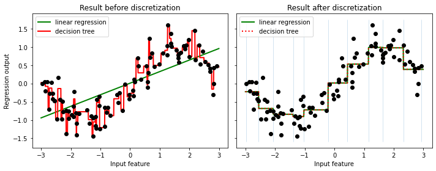

```python
# predict with original dataset
line = np.linspace(-3, 3, 1000, endpoint=False).reshape(-1, 1)
reg = LinearRegression().fit(X, y)

fig, (ax1, ax2) = plt.subplots(ncols=2, sharey=True, figsize=(10, 4))

ax1.plot(line, reg.predict(line), linewidth=2, color='green',
         label="linear regression")
reg = DecisionTreeRegressor(min_samples_split=3, random_state=0).fit(X, y)
ax1.plot(line, reg.predict(line), linewidth=2, color='red',
         label="decision tree")
ax1.plot(X[:, 0], y, 'o', c='k')
ax1.legend(loc="best")
ax1.set_ylabel("Regression output")
ax1.set_xlabel("Input feature")
ax1.set_title("Result before discretization")

# predict with transformed dataset
line_binned = enc.transform(line)
reg = LinearRegression().fit(X_binned, y)

ax2.plot(line, reg.predict(line_binned), linewidth=2, color='green',
         linestyle='-', label='linear regression')
reg = DecisionTreeRegressor(min_samples_split=3,
                            random_state=0).fit(X_binned, y)
ax2.plot(line, reg.predict(line_binned), linewidth=2, color='red',
         linestyle=':', label='decision tree')
ax2.plot(X[:, 0], y, 'o', c='k')
ax2.vlines(enc.bin_edges_[0], *plt.gca().get_ylim(), linewidth=1, alpha=.2)
ax2.legend(loc="best")
ax2.set_xlabel("Input feature")
ax2.set_title("Result after discretization")

plt.tight_layout()
```

### [Example: Feature discretization](https://scikit-learn.org/stable/auto_examples/preprocessing/plot_discretization_classification.html#sphx-glr-auto-examples-preprocessing-plot-discretization-classification-py)

- Feature discretization decomposes each feature into a set of equally distributed (width) bins. The values are one-hot encoded and given to a linear classifier. The preprocessing enables modeling non-linear behavior even though the classifier is linear.
- The first two rows represent linearly non-separable datasets (moons and concentric circles); the third is approximately linearly separable.
- Feature discretization increases the linear classifier performance on the non-separable datasets, but decreases performance on the third. Two non-linear classifiers are also shown for comparison.
- This is not a great example - the intuition conveyed does not carry over to real datasets.
  - High-D data can more easily be separated linearly.
  - Feature discretization and one-hot encoding increases the number of features, which easily lead to overfitting when the number of samples is small.
- Plots: training points = solid colors; testing points = semi-transparent. The lower right shows the classification accuracy on the test set.

```python
import numpy as np
import matplotlib.pyplot as plt
from matplotlib.colors import ListedColormap
from sklearn.model_selection import train_test_split
from sklearn.preprocessing import StandardScaler
from sklearn.datasets import make_moons, make_circles, make_classification
from sklearn.linear_model import LogisticRegression
from sklearn.model_selection import GridSearchCV
from sklearn.pipeline import make_pipeline
from sklearn.preprocessing import KBinsDiscretizer
from sklearn.svm import SVC, LinearSVC
from sklearn.ensemble import GradientBoostingClassifier
from sklearn.utils._testing import ignore_warnings
from sklearn.exceptions import ConvergenceWarning
```

```python
h = .02  # step size in the mesh


def get_name(estimator):
    name = estimator.__class__.__name__
    if name == 'Pipeline':
        name = [get_name(est[1]) for est in estimator.steps]
        name = ' + '.join(name)
    return name

classifiers = [
    (LogisticRegression(random_state=0), {
        'C': np.logspace(-2, 7, 10)
    }),
    (LinearSVC(random_state=0), {
        'C': np.logspace(-2, 7, 10)
    }),
    (make_pipeline(
        KBinsDiscretizer(encode='onehot'),
        LogisticRegression(random_state=0)), {
            'kbinsdiscretizer__n_bins': np.arange(2, 10),
            'logisticregression__C': np.logspace(-2, 7, 10),
        }),
    (make_pipeline(
        KBinsDiscretizer(encode='onehot'), LinearSVC(random_state=0)), {
            'kbinsdiscretizer__n_bins': np.arange(2, 10),
            'linearsvc__C': np.logspace(-2, 7, 10),
        }),
    (GradientBoostingClassifier(n_estimators=50, random_state=0), {
        'learning_rate': np.logspace(-4, 0, 10)
    }),
    (SVC(random_state=0), {
        'C': np.logspace(-2, 7, 10)
    }),
]

names = [get_name(e) for e, g in classifiers]

n_samples = 100
datasets = [
    make_moons(n_samples=n_samples, noise=0.2, random_state=0),
    make_circles(n_samples=n_samples, noise=0.2, factor=0.5, random_state=1),
    make_classification(n_samples=n_samples, n_features=2, n_redundant=0,
                        n_informative=2, random_state=2,
                        n_clusters_per_class=1)
]
```

```
dataset 0
---------
LogisticRegression: 0.86
LinearSVC: 0.86
KBinsDiscretizer + LogisticRegression: 0.86
KBinsDiscretizer + LinearSVC: 0.92
GradientBoostingClassifier: 0.90
SVC: 0.94

dataset 1
---------
LogisticRegression: 0.40
LinearSVC: 0.40
KBinsDiscretizer + LogisticRegression: 0.88
KBinsDiscretizer + LinearSVC: 0.86
GradientBoostingClassifier: 0.80
SVC: 0.84

dataset 2
---------
LogisticRegression: 0.98
LinearSVC: 0.98
KBinsDiscretizer + LogisticRegression: 0.94
KBinsDiscretizer + LinearSVC: 0.94
GradientBoostingClassifier: 0.88
SVC: 0.98
```

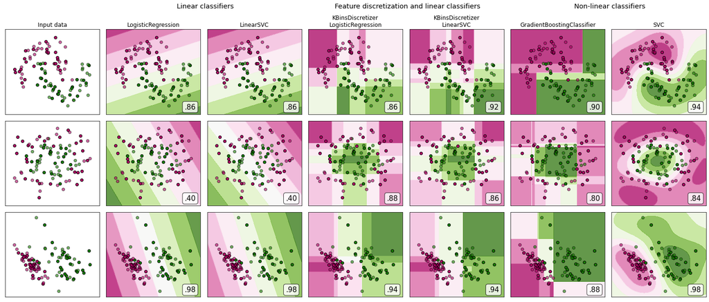

```python
fig, axes = plt.subplots(nrows=len(datasets), ncols=len(classifiers) + 1,
                         figsize=(21, 9))

cm = plt.cm.PiYG
cm_bright = ListedColormap(['#b30065', '#178000'])

# iterate over datasets
for ds_cnt, (X, y) in enumerate(datasets):
    print('\ndataset %d\n---------' % ds_cnt)

    # preprocess dataset, split into training and test part
    X = StandardScaler().fit_transform(X)
    X_train, X_test, y_train, y_test = train_test_split(
        X, y, test_size=.5, random_state=42)

    # create the grid for background colors
    x_min, x_max = X[:, 0].min() - .5, X[:, 0].max() + .5
    y_min, y_max = X[:, 1].min() - .5, X[:, 1].max() + .5
    xx, yy = np.meshgrid(
        np.arange(x_min, x_max, h), np.arange(y_min, y_max, h))

    # plot the dataset first
    ax = axes[ds_cnt, 0]
    if ds_cnt == 0:
        ax.set_title("Input data")
    # plot the training points
    ax.scatter(X_train[:, 0], X_train[:, 1], c=y_train, cmap=cm_bright,
               edgecolors='k')
    # and testing points
    ax.scatter(X_test[:, 0], X_test[:, 1], c=y_test, cmap=cm_bright, alpha=0.6,
               edgecolors='k')
    ax.set_xlim(xx.min(), xx.max())
    ax.set_ylim(yy.min(), yy.max())
    ax.set_xticks(())
    ax.set_yticks(())

    # iterate over classifiers
    for est_idx, (name, (estimator, param_grid)) in \
            enumerate(zip(names, classifiers)):
        ax = axes[ds_cnt, est_idx + 1]

        clf = GridSearchCV(estimator=estimator, param_grid=param_grid)
        with ignore_warnings(category=ConvergenceWarning):
            clf.fit(X_train, y_train)
        score = clf.score(X_test, y_test)
        print('%s: %.2f' % (name, score))

        # plot the decision boundary. For that, we will assign a color to each
        # point in the mesh [x_min, x_max]*[y_min, y_max].
        if hasattr(clf, "decision_function"):
            Z = clf.decision_function(np.c_[xx.ravel(), yy.ravel()])
        else:
            Z = clf.predict_proba(np.c_[xx.ravel(), yy.ravel()])[:, 1]

        # put the result into a color plot
        Z = Z.reshape(xx.shape)
        ax.contourf(xx, yy, Z, cmap=cm, alpha=.8)

        # plot the training points
        ax.scatter(X_train[:, 0], X_train[:, 1], c=y_train, cmap=cm_bright,
                   edgecolors='k')
        # and testing points
        ax.scatter(X_test[:, 0], X_test[:, 1], c=y_test, cmap=cm_bright,
                   edgecolors='k', alpha=0.6)
        ax.set_xlim(xx.min(), xx.max())
        ax.set_ylim(yy.min(), yy.max())
        ax.set_xticks(())
        ax.set_yticks(())

        if ds_cnt == 0:
            ax.set_title(name.replace(' + ', '\n'))
        ax.text(0.95, 0.06, ('%.2f' % score).lstrip('0'), size=15,
                bbox=dict(boxstyle='round', alpha=0.8, facecolor='white'),
                transform=ax.transAxes, horizontalalignment='right')


plt.tight_layout()

# Add suptitles above the figure
plt.subplots_adjust(top=0.90)
suptitles = [
    'Linear classifiers',
    'Feature discretization and linear classifiers',
    'Non-linear classifiers',
]
for i, suptitle in zip([1, 3, 5], suptitles):
    ax = axes[0, i]
    ax.text(1.05, 1.25, suptitle, transform=ax.transAxes,
            horizontalalignment='center', size='x-large')
```

### [KBinsDiscretizer strategy comparisons](https://scikit-learn.org/stable/auto_examples/preprocessing/plot_discretization_strategies.html#sphx-glr-auto-examples-preprocessing-plot-discretization-strategies-py)

- 'uniform' vs 'quantile' vs 'kmeans'
- The plots show regions where the encoding is constant.

```python
import numpy as np
import matplotlib.pyplot as plt

from sklearn.preprocessing import KBinsDiscretizer
from sklearn.datasets import make_blobs
```

```python
strategies = ['uniform', 'quantile', 'kmeans']

n_samples = 200
centers_0 = np.array([[0, 0], [0, 5], [2, 4], [8, 8]])
centers_1 = np.array([[0, 0], [3, 1]])

# construct the datasets
random_state = 42
X_list = [
    np.random.RandomState(random_state).uniform(-3, 3, size=(n_samples, 2)),

    make_blobs(n_samples=[n_samples // 10, n_samples * 4 // 10,
                          n_samples // 10, n_samples * 4 // 10],
               cluster_std=0.5,
               centers=centers_0,
               random_state=random_state)[0],

    make_blobs(n_samples=[n_samples // 5, n_samples * 4 // 5],
               cluster_std=0.5,
               centers=centers_1,
               random_state=random_state)[0],
]
```

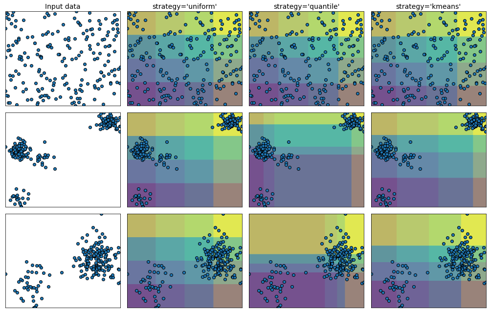

```python
figure = plt.figure(figsize=(14, 9))
i = 1
for ds_cnt, X in enumerate(X_list):

    ax = plt.subplot(len(X_list), len(strategies) + 1, i)
    ax.scatter(X[:, 0], X[:, 1], edgecolors='k')
    if ds_cnt == 0:
        ax.set_title("Input data", size=14)

    xx, yy = np.meshgrid(
        np.linspace(X[:, 0].min(), X[:, 0].max(), 300),
        np.linspace(X[:, 1].min(), X[:, 1].max(), 300))
    grid = np.c_[xx.ravel(), yy.ravel()]

    ax.set_xlim(xx.min(), xx.max())
    ax.set_ylim(yy.min(), yy.max())
    ax.set_xticks(())
    ax.set_yticks(())

    i += 1
    # transform the dataset with KBinsDiscretizer
    for strategy in strategies:
        enc = KBinsDiscretizer(n_bins=4, encode='ordinal', strategy=strategy)
        enc.fit(X)
        grid_encoded = enc.transform(grid)

        ax = plt.subplot(len(X_list), len(strategies) + 1, i)

        # horizontal stripes
        horizontal = grid_encoded[:, 0].reshape(xx.shape)
        ax.contourf(xx, yy, horizontal, alpha=.5)
        # vertical stripes
        vertical = grid_encoded[:, 1].reshape(xx.shape)
        ax.contourf(xx, yy, vertical, alpha=.5)

        ax.scatter(X[:, 0], X[:, 1], edgecolors='k')
        ax.set_xlim(xx.min(), xx.max())
        ax.set_ylim(yy.min(), yy.max())
        ax.set_xticks(())
        ax.set_yticks(())
        if ds_cnt == 0:
            ax.set_title("strategy='%s'" % (strategy, ), size=14)

        i += 1

plt.tight_layout()
```

### Feature Binarization

- Feature binarization *thresholds numerical features to get boolean values*. This is useful for downstream probabilistic estimators if input data can be described with a *multi-variate Bernoulli distribution*. For instance, this is the case for the BernoulliRBM.
- Text processing tasks use binary feature values (probably to simplify the probabilistic reasoning) even if normalized counts (a.k.a. term frequencies) or TF-IDF valued features often perform slightly better in practice.
- `Binarizer` is meant to be used in the early stages of a Pipeline. The fit method does nothing - each sample is treated independently of others.

```python
X = [[ 1., -1.,  2.],
     [ 2.,  0.,  0.],
     [ 0.,  1., -1.]]

binarizer = preprocessing.Binarizer().fit(X)  # fit does nothing
print(binarizer)
print(binarizer.transform(X))

# binarizer with adjusted threshold
binarizer = preprocessing.Binarizer(threshold=1.1)
print(binarizer.transform(X))
```

```
Binarizer()
[[1. 0. 1.]
 [1. 0. 0.]
 [0. 1. 0.]]
[[0. 0. 1.]
 [1. 0. 0.]
 [0. 0. 0.]]
```

### [Generating polynomial features](https://scikit-learn.org/stable/modules/generated/sklearn.preprocessing.PolynomialFeatures.html#sklearn.preprocessing.PolynomialFeatures)

- Example 1: transform X from $(X_1,X_2)$ to $(1,X_1,X_2,X^2_1,X_1X_2,X^2_2)$
- Example 2: (only feature interaction terms are required, via `interaction_only=True`): X features transformed from $(X_1, X_2, X_3)$ to $(1, X_1, X_2, X_3, X_1X_2, X_1X_3, X_2X_3, X_1X_2X_3)$.
- Polynomial features are used implicitly in [kernel methods](https://en.wikipedia.org/wiki/Kernel_method) when using polynomial [kernel functions](https://scikit-learn.org/stable/modules/svm.html#svm-kernels).

```python
import numpy as np
from sklearn.preprocessing import PolynomialFeatures

X    = np.arange(6).reshape(3, 2); print(X,"\n")
poly = PolynomialFeatures(2).fit_transform(X)
print(poly)
print()
# in some cases, only feature interaction terms are needed.
X    = np.arange(9).reshape(3, 3); print(X,"\n")
poly = PolynomialFeatures(degree=3,
                          interaction_only=True).fit_transform(X)
print(poly)
```

```
[[0 1]
 [2 3]
 [4 5]]

[[ 1.  0.  1.  0.  0.  1.]
 [ 1.  2.  3.  4.  6.  9.]
 [ 1.  4.  5. 16. 20. 25.]]

[[0 1 2]
 [3 4 5]
 [6 7 8]]

[[  1.   0.   1.   2.   0.   0.   2.   0.]
 [  1.   3.   4.   5.  12.  15.  20.  60.]
 [  1.   6.   7.   8.  42.  48.  56. 336.]]
```

### [Custom Transformers](https://scikit-learn.org/stable/modules/generated/sklearn.preprocessing.FunctionTransformer.html#sklearn.preprocessing.FunctionTransformer)

- Use `FunctionTransformer` to convert an existing Python function into a transformer.
- ensure `func` & `inverse_func` are indeed inverses by setting `check_inverse=True` and calling `fit` before `transform`. A warning is raised, and can be turned into an error with `filterwarnings`.

```python
import warnings
import numpy as np
from sklearn.preprocessing import FunctionTransformer as FT

warnings.filterwarnings("error",
                        message=".*check_inverse*.",
                        category=UserWarning,
                        append=False)

transformer = FT(np.log1p, validate=True)
X           = np.array([[0, 1], [2, 3]])
transformer.transform(X)
```

```
array([[0.        , 0.69314718],
       [1.09861229, 1.38629436]])
```